# RDD

Yu-Ting Huang

2/15/2021

#### Github repo and summary (worth 2 points)

```
1. Download Hansen_dwi.dta from github at the following address.
```

use https://github.com/scunning1975/causal-inference-class/raw/master/hansen_dwi, clear

Create a new github repo named “RDD”. Inside the RDD directory, put all the subdirectories we’ve discussed in class. Post the link to the repo so I can see it’s done as discussed in your assignment. Save the Hansen_dwi.dta file into your new /data subdirectory. Note: The outcome variable is “recidivism” or “recid” which is measuring whether the person showed back up in the data within 4 months.

https://github.com/Reina-Huang/RDD.git

[output not shown]

The main question for this paper is that the authors would like to realize whether punishments and sanctions are effective in decreasing drunk driving. They claim this finding is important for improving social welfare, and could assist to formulate the related policy. In order to further construct the model, he utilize administrative records on 512,964 DUI BAC tests in the state of Washington from 1999 to 2007. The reason is that BAC thresholds are the same after 1999 which is 0.08 and 0.15 (aggravated).

Owing to the quantifiable characteristics of BAC, authors could apply local linear regression discontinuity design to do the estimates. In addition, the evidences also show that demographic indicators such as age, white/nonwhite and male/female keep constant in the DUI punishment thresholds. The identification strategy is that allowing the slopes change at the certain DUI (0.08) and severe DUI (0.15) threshold. To meet the expectation, they assumes recidivism may decrease at specific points if punishment and sanctions have effect.

Finally, they point out recidivism will declining two percentages points which is statistically significant as BAC above the 0.08 threshold during a four year follow-up. Furthermore, conclusion also present people have lower possibilities to repeatedly drunk drive though people do not have previous tests. In other words, consequence means punishment and sanctions have advantages of reducing repeat drunk drivers for both 0.08 DUI threshold and 0.15 aggravated DUI in the short and long run.

#### Reproducing somewhat Hansen’s results (but just follow directions) (worth 6 points).[2]

[output not shown]

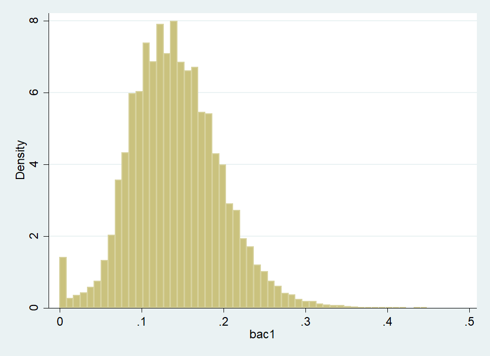

[figure not shown]

[output not shown]

```
5. The second thing we need to do is check for covariate balance. Recreate Table 2 Panel A but only white male, age and accident (acc) as dependent variables.  Use your equation 1) for this. Are the covariates balanced at the cutoff?  It’s okay if they are not exactly the same as Hansen’s.
```

```
6. Recreate Figure 2 panel A-D. You can use the -cmogram- command in Stata to do this. Fit both linear and quadratic with confidence intervals. Discuss what you find and compare it with Hansen’s paper.
```

[output not shown]

```
8. Recreate the top panel of Figure 3 according to the following rule:
Fit linear fit using only observations with less than 0.15 bac on the bac1
Fit quadratic fit using only observations with less than 0.15 bac on the bac1
```

[output not shown]

[1] Again, my preference is that you attempt to create automated tables and automated figures as much as you can. I’ve placed a simple estout program called ols.do in the estout subdirectory. You just need to edit.

[2] Much of this advice applies to Stata commands, but you can check the R files for lmb.r to see ways of doing the same in R.